# Projet Green AI : Détection des déchets dans l'océan

##### Ovia Chanemouganandam, Sandrine Daniel, Léo-Paul Chauvigné, Timothée Joliot, Hannah-May Littière et Yann Lin – DIA 4

# Contexte et structure du projet

Ce notebook retrace l’ensemble de notre démarche dans le cadre du projet **Green AI** :

- une **première piste de travail** autour de la **corrélation entre consommation électrique et irradiation solaire**, à partir de données publiques (données de consommation, jeux de données météo NASA, etc.) ;
- puis la **redéfinition de notre problématique** et le choix d’un **sujet final** : la **détection de déchets marins dans l’océan à partir d’images satellites** (dataset MARIDA).

L’objectif du projet n’est pas uniquement d’atteindre la meilleure performance possible, mais de :

- formuler une **problématique socio-environnementale claire** ;
- **explorer et comprendre les données** (qualité, variabilité, limites) ;
- **tester plusieurs approches de modélisation** avec un regard critique ;
- **mesurer et discuter l’impact environnemental** de nos choix (complexité des modèles, temps de calcul, usages possibles) ;
- et **documenter notre cheminement**, y compris les idées abandonnées en cours de route.

Dans ce notebook :

1. Nous présentons d’abord notre **première idée** sur la consommation électrique et l’irradiation : hypothèses, mise en place des données, pistes d’analyse, puis les raisons pour lesquelles nous avons finalement **décidé de ne pas retenir ce sujet**.
2. Nous détaillons ensuite notre **projet final**, centré sur la **détection de déchets marins** à partir d’images satellites du dataset **MARIDA**, avec :
   - le prétraitement des données et la construction des DataLoaders,
   - l’entraînement de modèles de segmentation (U-Net, ResNet, puis VGG16),
   - l’évaluation des performances (F1,matrice de confusion),
   - une discussion sur l’angle **Green AI** : sobriété, limites et cas d’usage potentiel.

Ce notebook constitue ainsi la trace complète de notre démarche : essais, ajustements, changements de direction et résultats finaux.

```python
import os
os.environ['CUDA_LAUNCH_BLOCKING'] = "1"
import torch
import matplotlib.pyplot as plt
import seaborn as sns


from torch.utils.data import DataLoader
import sys
import torch.nn as nn
import torch.optim as optim

from dataset import (
    MaridaDatasetLoader,
    find_patch_bases,
    do_img_conf_mask_exist,
)
from preprocessing import (
    normalize_image,
    set_low_conf_for_nan,
    apply_augmentations,
    build_conf_ignore_mask,
    apply_ignore_index_to_target,
    flatten_for_rf,
    compute_dataset_stats,
)

from sklearn.ensemble import RandomForestClassifier
from sklearn.model_selection import train_test_split
from sklearn.metrics import accuracy_score, classification_report, confusion_matrix
from matplotlib.colors import LogNorm
from sklearn.metrics import confusion_matrix
import seaborn as sns
import matplotlib.pyplot as plt
import numpy as np

from tqdm import tqdm
from sklearn.metrics import classification_report, f1_score, jaccard_score
from unet import UNet
```

# **1. Premières idées de projet**

### **1. Première idée**

Au départ, nous avions choisi une problématique liée à la prédiction du potentiel de production d’énergie solaire à partir de données météorologiques locales.

- Problématique initiale : Peut-on estimer la quantité d’énergie solaire (en kWh/m²) produite dans une zone donnée à partir de variables météorologiques telles que l’irradiation, la température, la couverture nuageuse, l’humidité ou encore la vitesse du vent ?

Cependant, ce sujet s’est révélé trop vague et ne faisait finalement pas appel à de véritables modèles d’IA. En pratique, notre approche ne consistait pas à effectuer une prédiction complexe, mais plutôt à appliquer une fonction relativement simple à partir de l’irradiation, un paramètre déjà fortement corrélé à la production solaire. La tâche devenait alors essentiellement un calcul direct plutôt qu’un apprentissage réel, ce qui limitait fortement l’intérêt et la profondeur du projet.

Nous avons beaucoup tourné autour de l'idée des panneaux solaires sans réellement trouver de problématique intéressante et challengeante

### **2. Deuxième idée**

Nous avons essayé d'approfondir la piste que vous nous aviez suggérée :

- Quelles zones géographiques présentent une évolution journalière de la consommation d’électricité qui suit le même rythme que l’ensoleillement local, indiquant un fort potentiel d’autoconsommation solaire ?

Les datasets trouvés :

- eco2mix pour la consommation d’électricité par métropole: https://odre.opendatasoft.com/explore/dataset/eco2mix-metropoles-tr/information/?flg=fr-fr&disjunctive.libelle_metropole&disjunctive.nature
- NASA POWER pour les données météorologiques horaires: https://power.larc.nasa.gov/data-access-viewer/

```python
import pandas as pd
import numpy as np
import matplotlib.pyplot as plt
import os
```

Première partie d'exploration des datasets avec l'analyse d'un exemple sur une ville en particulier. Fusion des deux datasets selon la variable datetime.

```python
#BASE_PATH = "data/ancien_data/"
BASE_PATH = ""

def load_nasa_hourly(csv_path):
    """
    Charge un fichier NASA POWER horaire et renvoie un DataFrame
    avec une colonne datetime et les variables météo.
    """
    #Détecter la ligne d'entête
    header_row = None
    with open(csv_path, 'r') as f:
        for i, line in enumerate(f):
            if line.startswith("YEAR,MO,DY,HR"):
                header_row = i
                break
    if header_row is None:
        raise ValueError(f"Impossible de trouver la ligne d'entête dans {csv_path}")

    df = pd.read_csv(csv_path, header=header_row)

    #Construire un datetime
    df['datetime'] = pd.to_datetime(
        df[['YEAR', 'MO', 'DY', 'HR']].rename(
            columns={'YEAR': 'year', 'MO': 'month', 'DY': 'day', 'HR': 'hour'}
        )
    )

    #Garder juste ce qui nous intéresse
    cols_to_keep = ['datetime', 'ALLSKY_SFC_SW_DWN', 'T2M', 'RH2M', 'WS10M', 'PRECTOTCORR']
    cols_to_keep = [c for c in cols_to_keep if c in df.columns]
    df = df[cols_to_keep].sort_values('datetime')

    return df
```

```python
def load_eco2mix_metropole(csv_path, metropole_name):
    """
    Charge le fichier eco2mix-metropoles-tr filtré sur une métropole.
    Renvoie un DataFrame avec datetime + consommation (MW).
    """
    df = pd.read_csv(csv_path, sep=';')

    #Filtrer la métropole voulue
    df = df[df['Métropole'] == metropole_name].copy()

    #Convertir la colonne Date  Heure en datetime
    df['datetime'] = pd.to_datetime(df['Date - Heure'])
    df = df.sort_values('datetime')

    # Garder les colonnes importantes
    df = df[['datetime', 'Consommation (MW)']]

    return df
```

```python
#ECO2MIX_PATH = "/home/ovia/satellite_image_ocean_trash_detector/data/ancien_data/eco2mix-metropoles-tr.csv"
ECO2MIX_PATH = "../data/project_not_selected/eco2mix-metropoles-tr.csv"

#df_nasa = load_nasa_hourly("/home/ovia/satellite_image_ocean_trash_detector/data/ancien_data/Bordeaux_POWER_Point_Hourly_20220101_20241231_044d84N_000d58W_LST.csv")
df_nasa = load_nasa_hourly("../data/project_not_selected/Bordeaux_POWER_Point_Hourly_20220101_20241231_044d84N_000d58W_LST.csv")

df_eco = pd.read_csv(ECO2MIX_PATH, sep=';')

metropole_name = "Bordeaux Métropole"
df_eco = df_eco[df_eco['Métropole'] == metropole_name].copy()


df_eco['datetime'] = pd.to_datetime(df_eco['Date - Heure'], utc=True, errors='coerce')

#enlever les lignes mal parsées (au cas où)
df_eco = df_eco.dropna(subset=['datetime'])


df_eco['datetime'] = (
    df_eco['datetime']
    .dt.tz_convert('Europe/Paris')   # passer en heure locale
    .dt.tz_localize(None)           # enlever l'info de fuseau
)


print(df_eco['datetime'].dtype)


df_eco = df_eco.set_index('datetime')

print(type(df_eco.index), df_eco.index.dtype)

eco_hourly = (
    df_eco
    .resample('h')['Consommation (MW)']
    .mean()
    .reset_index()
)

eco_hourly.head()
```

```
datetime64[ns]
<class 'pandas.core.indexes.datetimes.DatetimeIndex'> datetime64[ns]
```

|  | datetime | Consommation (MW) |
| --- | --- | --- |
| 0 | 2022-01-01 00:00:00 | 678.75 |
| 1 | 2022-01-01 01:00:00 | 681.50 |
| 2 | 2022-01-01 02:00:00 | 684.25 |
| 3 | 2022-01-01 03:00:00 | 645.50 |
| 4 | 2022-01-01 04:00:00 | 623.25 |

```python
# NASA est déjà horaire mais on s'assure que c'est propre
nasa_hourly = (
    df_nasa
    .set_index('datetime')
    .resample('h').mean()
    .reset_index()
)
nasa_hourly.head()
```

|  | datetime | ALLSKY_SFC_SW_DWN | T2M | RH2M | WS10M | PRECTOTCORR |
| --- | --- | --- | --- | --- | --- | --- |
| 0 | 2022-01-01 00:00:00 | 0.0 | 6.50 | 100.00 | 3.54 | 0.36 |
| 1 | 2022-01-01 01:00:00 | 0.0 | 6.26 | 100.00 | 3.63 | 0.26 |
| 2 | 2022-01-01 02:00:00 | 0.0 | 6.24 | 96.51 | 3.80 | 0.17 |
| 3 | 2022-01-01 03:00:00 | 0.0 | 6.27 | 88.60 | 3.91 | 0.02 |
| 4 | 2022-01-01 04:00:00 | 0.0 | 6.23 | 82.33 | 3.75 | 0.02 |

```python
#Fusion sur datetime (inner pour garder les heures communes)
df_merged = pd.merge(
    eco_hourly,
    nasa_hourly,
    on='datetime',
    how='inner'
)

df_merged.head()
```

|  | datetime | Consommation (MW) | ALLSKY_SFC_SW_DWN | T2M | RH2M | WS10M | PRECTOTCORR |
| --- | --- | --- | --- | --- | --- | --- | --- |
| 0 | 2022-01-01 00:00:00 | 678.75 | 0.0 | 6.50 | 100.00 | 3.54 | 0.36 |
| 1 | 2022-01-01 01:00:00 | 681.50 | 0.0 | 6.26 | 100.00 | 3.63 | 0.26 |
| 2 | 2022-01-01 02:00:00 | 684.25 | 0.0 | 6.24 | 96.51 | 3.80 | 0.17 |
| 3 | 2022-01-01 03:00:00 | 645.50 | 0.0 | 6.27 | 88.60 | 3.91 | 0.02 |
| 4 | 2022-01-01 04:00:00 | 623.25 | 0.0 | 6.23 | 82.33 | 3.75 | 0.02 |

Après avoir fait de premiers tests avec les datasets d'une ville en particulier et avoir bien réussi à les fusionner on va pouvoir s'étendre à toutes nos villes en construisant des fonctions pour répéter le processus d'importation et de fusion de dataset pour chaque ville.

```python
# Dictionnaire NASA pour plusieurs villes
NASA_FILES = {
    "Bordeaux Métropole": os.path.join(
        BASE_PATH,
        "Bordeaux_POWER_Point_Hourly_20220101_20241231_044d84N_000d58W_LST.csv"
    ),
    "Métropole de Lyon": os.path.join(
        BASE_PATH,
        "Lyon_POWER_Point_Hourly_20220101_20241231_045d77N_004d83E_LST.csv"
    ),
    "Métropole Européenne de Lille": os.path.join(
        BASE_PATH,
        "Lille_POWER_Point_Hourly_20220101_20241231_050d63N_003d06E_LST.csv"
    ),
    "Métropole d'Aix-Marseille-Provence": os.path.join(
        BASE_PATH,
        "Marseille_POWER_Point_Hourly_20220101_20241231_043d29N_005d37E_LST.csv"
    ),
    "Métropole du Grand Paris": os.path.join(
        BASE_PATH,
        "Paris_POWER_Point_Hourly_20220101_20241231.csv"
    ),
    "Dijon Métropole": os.path.join(
        BASE_PATH,
        "Dijon_POWER_Point_Hourly_20220101_20241231_047d33N_005d04E_LST.csv"
    ),
}

def load_eco2mix_hourly_for_metropole(csv_path, metropole_name):
    """
    Charge eco2mix pour une métropole, convertit la date en Europe/Paris
    et agrège en horaire.
    """
    df = pd.read_csv(csv_path, sep=';')
    df = df[df['Métropole'] == metropole_name].copy()

    # Datetime avec timezone + conversion Europe/Paris
    df['datetime'] = pd.to_datetime(df['Date - Heure'], utc=True, errors='coerce')
    df = df.dropna(subset=['datetime'])
    df['datetime'] = df['datetime'].dt.tz_convert('Europe/Paris').dt.tz_localize(None)

    #Agrégation horaire
    df = (
        df.set_index('datetime')
          .resample('h')['Consommation (MW)']
          .mean()
          .reset_index()
    )
    return df

def build_merged_for_city(metropole_name):
    """
    Charge NASA + eco2mix pour une ville, met tout à l'heure
    et renvoie un df fusionné avec :
      datetime, Consommation (MW), ALLSKY_SFC_SW_DWN, ...
    """
    nasa_path = NASA_FILES[metropole_name]
    df_nasa = load_nasa_hourly(nasa_path)
    df_eco_hourly = load_eco2mix_hourly_for_metropole(ECO2MIX_PATH, metropole_name)

    nasa_hourly = (
        df_nasa
        .set_index('datetime')
        .resample('h')
        .mean()
        .reset_index()
    )

    df_merged = pd.merge(
        df_eco_hourly,
        nasa_hourly,
        on='datetime',
        how='inner'
    )
    return df_merged
```

```python
def norm01(x):
  """Fonction qui normalise une variable"""
  x = x.astype(float)
  xmin, xmax = x.min(), x.max()
  rng = xmax - xmin
  if rng == 0:
      return np.zeros_like(x)
  return (x - xmin) / rng
```

On utilise ici le premier exemple qu'on a crée afin de visualiser sur une courte période comment se comportent les courbes de la consommation électrique et l'irradiation.

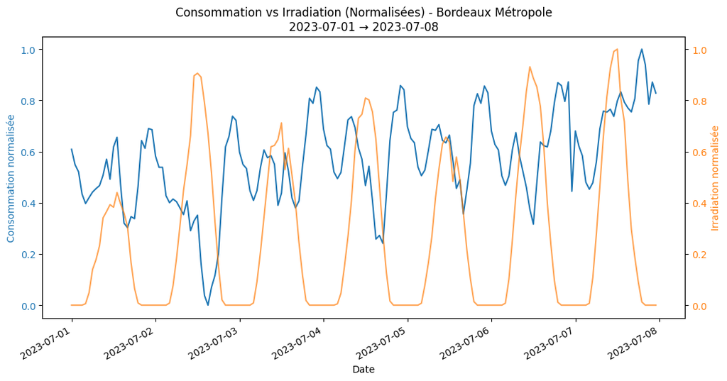

```python
#Comparaison des courbes normalisées entre la consommation électrique et l'irradiation de la métropole
start = "2023-07-01"
end   = "2023-07-08"

mask = (df_merged['datetime'] >= start) & (df_merged['datetime'] < end)
df_week = df_merged[mask].copy()

df_week['cons_norm'] = norm01(df_week['Consommation (MW)'].values)
df_week['irr_norm']  = norm01(df_week['ALLSKY_SFC_SW_DWN'].values)

fig, ax1 = plt.subplots(figsize=(12, 6))

# Courbe consommation normalisée
ax1.plot(
    df_week['datetime'],
    df_week['cons_norm'],
    label="Consommation (normalisée)",
    color="tab:blue"
)
ax1.set_xlabel("Date")
ax1.set_ylabel("Consommation normalisée", color="tab:blue")
ax1.tick_params(axis='y', labelcolor="tab:blue")

# Courbe irradiation normalisée
ax2 = ax1.twinx()
ax2.plot(
    df_week['datetime'],
    df_week['irr_norm'],
    label="Irradiation (normalisée)",
    color="tab:orange",
    alpha=0.7
)
ax2.set_ylabel("Irradiation normalisée", color="tab:orange")
ax2.tick_params(axis='y', labelcolor="tab:orange")

fig.autofmt_xdate()
plt.title(f"Consommation vs Irradiation (Normalisées) - {metropole_name}\n{start} → {end}")
plt.show()
```

Ici les courbes sont assez éloignées, presques à l'opposé l'une de l'autre donc difficile d'y trouver une corrélation. En particulier la nuit l'irradiation est nulle et s'est à ces moments de la journée qu'on a des pics de consommation.

```python
def compute_daily_shape_metrics(df_merged):
    """
    Pour un df_merged (une ville), calcule pour chaque journée :
    - corrélation entre conso & irradiation après normalisation
    - MSE entre les deux formes normalisées

    Renvoie un DataFrame indexé par date, avec colonnes:
    ['mse_shape', 'corr_shape']
    """
    df = df_merged.copy()

    # On vérifie qu'on a bien les colonnes nécessaires
    required_cols = ['datetime', 'Consommation (MW)', 'ALLSKY_SFC_SW_DWN']
    for c in required_cols:
        if c not in df.columns:
            print(f"Colonne manquante dans df_merged : {c}")
            return pd.DataFrame(columns=['mse_shape', 'corr_shape'])

    df = df.set_index('datetime')
    df['date'] = df.index.date
    df['hour'] = df.index.hour

    rows = []

    for date_val, g in df.groupby('date'):
        # On veut une vraie journée (par ex. au moins 12 heures)
        if g['hour'].nunique() < 12:
            continue

        g = g.sort_values('hour')
        cons = g['Consommation (MW)'].values
        irr  = g['ALLSKY_SFC_SW_DWN'].values

        # Si tout est NaN côté irradiation, on saute
        if np.all(np.isnan(irr)) or np.all(np.isnan(cons)):
            continue

        cons_n = norm01(cons)
        irr_n  = norm01(irr)

        mse = np.mean((cons_n - irr_n) ** 2)

        if cons_n.std() == 0 or irr_n.std() == 0:
            corr = np.nan
        else:
            corr = np.corrcoef(cons_n, irr_n)[0, 1]

        rows.append({
            'date': date_val,
            'mse_shape': mse,
            'corr_shape': corr
        })

    if not rows:
        #aucune journée exploitable
        return pd.DataFrame(columns=['mse_shape', 'corr_shape']).set_index('date')

    daily = pd.DataFrame(rows).set_index('date')
    return daily
```

```python
cities_metrics = {}

for metro_name in NASA_FILES.keys():
    try:
        df_merged_city = build_merged_for_city(metro_name)
        daily_metrics = compute_daily_shape_metrics(df_merged_city)
        #print(daily_metrics.head())
        if daily_metrics.empty:
            print(f"Pas de journées exploitables pour {metro_name} (daily_metrics vide)")
            continue

        mean_corr = daily_metrics['corr_shape'].mean()
        mean_mse  = daily_metrics['mse_shape'].mean()

        cities_metrics[metro_name] = {
            "df_merged": df_merged_city,
            "daily_metrics": daily_metrics,
            "mean_corr": mean_corr,
            "mean_mse": mean_mse,
        }

        print(
            f"{metro_name} -> corr moy = {mean_corr:.3f}, "
            f"MSE moy = {mean_mse:.3f}"
        )

    except Exception as e:
        print(f"Erreur pour {metro_name} : {e}")
```

[output not shown]

```python
for metro_name, info in cities_metrics.items():
    daily_metrics = info["daily_metrics"]

    plt.figure()
    daily_metrics['corr_shape'].hist(bins=20)
    plt.title(f"Distribution des corrélations de forme conso/irradiation\n{metro_name}")
    plt.xlabel("Corrélation (formes normalisées)")
    plt.ylabel("Nombre de journées")
    plt.show()
```

[output not shown]

# Pourquoi nous n’avons finalement pas retenu ce sujet

L’objectif initial de ce projet était d’identifier les zones géographiques les plus adaptées à l’installation de panneaux solaires en comparant, pour chaque ville, l’évolution horaire de l’irradiation solaire et celle de la consommation électrique. L’idée était qu’un bon « alignement de forme » entre ces deux courbes traduirait une pertinence énergétique pour l’autoconsommation solaire.

Après plusieurs phases d’exploration, de collecte de données (NASA POWER pour la météo, eco2mix pour la consommation) et de mise en correspondance temporelle, nous avons pu calculer des indicateurs de similarité basés sur la corrélation et l’erreur quadratique moyenne entre les formes journalières normalisées. Cependant, bien que cette démarche soit méthodologiquement correcte, les résultats obtenus et les limites rencontrées nous ont conduits à ne pas retenir ce sujet pour une étude basée sur des modèles d’IA.

Malgré la richesse apparente des données météorologiques (irradiation, température, humidité, vent…), les résultats finaux reposent presque exclusivement sur la variable irradiation solaire. La consommation électrique, elle, dépend d’une multitude de facteurs sociaux, économiques et comportementaux qui n’ont aucun lien direct avec la météorologie.

- Le lien “conso - irradiation” reste mécaniquement faible, sauf dans quelques métropoles.
- Ajouter d’autres variables météo (température, humidité, vent…) n’améliorerait pas la corrélation puisque ces paramètres influencent peu la forme de la courbe de consommation quotidienne.

L’analyse reste donc uniquement un test de corrélation forme contre forme, sans réelles interactions multivariées exploitables.

Ces valeurs confirment qu’il existe peu de dépendance structurelle entre conso et ensoleillement, montrent une variabilité importante, et ne permettent pas de conclure de manière robuste sur un potentiel solaire “naturel” basé sur la synchronisation des deux signaux.

Même les villes qui obtiennent des scores plus élevés ne montrent pas une cohérence suffisante pour justifier un classement fiable ou une prédiction future.

# **2. Deuxième et idée finale de notre projet**

## Détection de déchets marins à partir d’images satellites (MARIDA)

Après avoir exploré et finalement écarté notre première idée autour de la corrélation entre consommation électrique et irradiation solaire, nous avons recentré notre projet sur une problématique plus directement liée à la **pollution des océans**.

L’objectif de cette deuxième idée, qui est devenu notre **sujet final**, est de tester dans quelle mesure un modèle de **vision par ordinateur** peut aider à identifier des **déchets marins** à partir d’images satellites, tout en restant dans une démarche de **Green AI** (modèles sobres, analyse critique de l’impact environnemental).

### Problématique

> Peut-on entraîner un modèle de segmentation, à partir du dataset **MARIDA**, capable de repérer les zones contenant des déchets marins sur des images satellitaires, avec une performance correcte et un coût de calcul raisonnable ?

Cette question se situe à l’intersection de :

- la **protection des océans** (déchets, plastiques, mousse, sargasses, etc.) ;
- la **télédétection** (images Sentinel-2 découpées en patchs) ;
- et la **sobriété du machine learning** (choix de modèles simples, entraînements limités, discussion de l’impact carbone).

### Données : le dataset MARIDA

Nous utilisons le dataset **MARIDA** (https://zenodo.org/records/5151941), qui fournit :

- des **patchs d’images satellites** multi-canaux (11 bandes),
- des **masques de segmentation** multi-classes (débris, sargasses, eau, nuages, vagues, etc.),
- une **carte de confiance** associée à chaque pixel (certain, moins sûr, incertain), qui nous permet de **masquer ou ignorer** certaines annotations pendant l’apprentissage.

Les difficultés principales sont :

- la **très faible taille relative** des débris par rapport à la résolution de l’image ;
- la **variabilité visuelle de la mer** (couleur, profondeur, glint, algues, écume) ;
- le **déséquilibre des classes** (l’eau domine largement, les débris sont rares).

### Approche de modélisation

Dans cette partie du notebook, nous :

1. Construisons des **DataLoaders** PyTorch pour MARIDA (train / validation), avec :
   - prétraitement des images (normalisation),
   - transformations de data augmentation pour le train,
   - prise en compte de la **confidence map** pour ignorer certains pixels dans la loss.
2. Testons plusieurs **modèles de segmentation** :
   - un **U-Net** de base (importé depuis `unet.py`),
   - un modèle de segmentation basé sur **ResNet34** (`ResNetSeg`) adapté à 11 canaux en entrée et 15 classes en sortie,
   - et un futur modèle basé sur **VGG16** (même principe : backbone de classification réadapté à la segmentation).
3. Utilisons une **CrossEntropyLoss pondérée**, afin de donner plus de poids aux classes rares (débris, mousse, écume) et moins de poids aux classes très fréquentes (eau).
4. Évaluons les modèles avec :
   - des métriques globales (F1-score),
   - une **matrice de confusion** entre classes,
   - une analyse qualitative des erreurs (par exemple confusion entre écume, vagues, plastique…).

Nous discutons enfin :

- du **rapport entre complexité du modèle et gain de performance** (U-Net vs ResNet vs VGG16) ;
- du **coût computationnel** de l’entraînement (temps, GPU utilisé, électricité en France) ;
- des **limites actuelles** (performance encore moyenne, tâche très difficile, incertitude sur l’impact réel sur le terrain) ;
- et des **perspectives** : comment ce type de modèle pourrait, à terme, aider à **prioriser les zones d’intérêt** pour des acteurs qui travaillent sur la pollution marine.

L’objectif n’est donc pas de prétendre “résoudre” la détection des déchets marins, mais de proposer une **preuve de concept réfléchie**, documentée et alignée avec les principes du **Green AI**.

## **1.Pré-processing**

1. Définition des chemins

```python
PROJECT_PATH = os.path.join(os.getcwd(), "../")
# On ajoute 'src' au système pour les imports
sys.path.append(os.path.join(PROJECT_PATH, "src"))

# On définit les chemins de données

DATA_ROOT = os.path.join(os.getcwd(), "../","data", "raw","MARIDA")
PATCHES_DIR = os.path.join(DATA_ROOT, "patches")
SPLITS_DIR = os.path.join(DATA_ROOT, "splits")

print(f" Dossier Patches : {PATCHES_DIR}")
print(f" Dossier Textes : {SPLITS_DIR}")
```

```
 Dossier Patches : /home/leopa/projects/satellite_image_ocean_trash_detector/src/../data/raw/MARIDA/patches
 Dossier Textes : /home/leopa/projects/satellite_image_ocean_trash_detector/src/../data/raw/MARIDA/splits
```

2. Transformation et fonctions utilitaires

```python
def train_transform(img, mask, conf):
    img, conf = set_low_conf_for_nan(img, conf, low_conf_level=3)
    img = normalize_image(img)
    img, mask, conf = apply_augmentations(img, mask, conf)
    return img, mask, conf

def val_transform(img, mask, conf):
    img, conf = set_low_conf_for_nan(img, conf, low_conf_level=3)
    img = normalize_image(img)
    return img, mask, conf

def get_valid_bases(split_filename, patches_root):
    split_path = os.path.join(SPLITS_DIR, split_filename)
    if not os.path.exists(split_path):
        print(f" Fichier texte manquant : {split_path}")
        return []

    valid_bases = []
    with open(split_path, 'r') as f:
        lines = f.readlines()

    print(f" Lecture de {split_filename}...")
    for line in lines:
        name = line.strip()
        if not name: continue

        # Correction du nom : Ajout de S2_
        base_name = "S2_" + name
        folder_name = base_name.rsplit('_', 1)[0]
        relative_path = os.path.join(folder_name, base_name)

        # Vérification
        if os.path.exists(os.path.join(patches_root, relative_path + ".tif")):
            valid_bases.append(relative_path)

    print(f"    {len(valid_bases)} images trouvées.")
    return valid_bases
```

```python
def build_conf_ignore_mask(conf: torch.Tensor, threshold: int = 2,
    ) -> torch.Tensor:
    """
    Build a boolean mask where pixels with confidence > threshold are ignored.
    1: High - keep
    2: Moderate - keep
    3: Low - we ignore
    Args:
        conf: (H, W) integer confidence levels.
        threshold: keep pixels with conf <= threshold.
    Returns:
        ignore_mask: (H, W) bool tensor, True = IGNORE this pixel.
    """
    ignore_mask = conf > threshold
    return ignore_mask


def apply_ignore_index_to_target( target: torch.Tensor, ignore_mask: torch.Tensor, ignore_index: int = -100,
    ) -> torch.Tensor:
    """
    The function sets target pixels to ignore_index where ignore_mask is True.
    Args:
        target: (H, W) class ids.
        ignore_mask: (H, W) bool.
        ignore_index: value used in loss
    Returns:
        target_mod: (H, W) with some pixels set to ignore_index.
    """
    target_mod = target.clone()
    target_mod[ignore_mask] = ignore_index
    return target_mod
```

3. Création des listes d'images et des DataLoaders

```python
train_bases = get_valid_bases("train_X.txt", PATCHES_DIR)
val_bases = get_valid_bases("val_X.txt", PATCHES_DIR)

if len(train_bases) == 0:
    raise ValueError(" ERREUR : Aucune image trouvée. Vérifiez le chemin DATA_ROOT.")

train_dataset = MaridaDatasetLoader(PATCHES_DIR, train_bases, transform=train_transform)
val_dataset = MaridaDatasetLoader(PATCHES_DIR, val_bases, transform=val_transform)

BATCH_SIZE = 8
num_workers = 2

train_loader = DataLoader(train_dataset, batch_size=BATCH_SIZE, shuffle=True, num_workers=num_workers)
val_loader = DataLoader(val_dataset, batch_size=BATCH_SIZE, shuffle=False, num_workers=num_workers)
```

```
 Lecture de train_X.txt...
    694 images trouvées.
 Lecture de val_X.txt...
    328 images trouvées.
```

## **2. Application des modèles**

### **Modèle 1 : U-Net**

1. Pondération des classes

On donne un gros poids aux classes rares (Débris, Mousse) et un petit poids aux classes fréquentes (Eau) Débris (Class 0) a un poids de 50, l'Eau (Class 7) a un poids de 0.1

```python
DEVICE = torch.device("cuda" if torch.cuda.is_available() else "cpu")
print(f" Démarrage sur : {DEVICE}")
```

```
 Démarrage sur : cuda
```

```python
class_weights = torch.tensor([
    50.0,  # 0: Débris Marins (TRÈS IMPORTANT)
    5.0,   # 1: Sargasses Denses
    10.0,  # 2: Sargasses Éparses
    20.0,  # 3: Matière Organique (Rare)
    5.0,   # 4: Navire
    0.5,   # 5: Nuages (Fréquent, facile)
    0.2,   # 6: Eau Marine (Très fréquent)
    0.1,   # 7: Eau Sédimentaire (Trop fréquent, on le calme)
    20.0,  # 8: Écume (Difficile, ressemble au plastique)
    0.5,   # 9: Eau Trouble
    10.0,  # 10: Eau Peu Profonde
    10.0,  # 11: Vagues
    5.0,   # 12: Ombre
    5.0,   # 13: Sillage
    10.0   # 14: Mixte
]).to(DEVICE)
```

2. Modèle, loss et optimizer

```python
model = UNet(n_channels=11, n_classes=15).to(DEVICE)

# Optimiseur
optimizer = optim.Adam(model.parameters(), lr=1e-4)

# Loss avec poids + ignore_index
criterion = nn.CrossEntropyLoss(weight=class_weights, ignore_index=-100)

EPOCHS = 15

print("Loss pondérée activée : les débris sont 50x plus importants que l'eau.")
```

```
Loss pondérée activée : les débris sont 50x plus importants que l'eau.
```

3. Boucle d'entraînement

```python
print("\n Lancement de la boucle d'entraînement...")

for epoch in range(EPOCHS):
    model.train()
    epoch_loss = 0
    loop = tqdm(train_loader, desc=f"Epoch {epoch+1}/{EPOCHS}")

    for img, mask, conf in loop:
        img = img.to(DEVICE)
        mask = mask.to(DEVICE)
        conf = conf.to(DEVICE)

        ignore_mask = build_conf_ignore_mask(conf, threshold=2)
        target = apply_ignore_index_to_target(mask, ignore_mask, ignore_index=-100)

        valid = (target != -100)
        target[valid] = target[valid] - 1
        target[target == -1] = -100

        optimizer.zero_grad()
        outputs = model(img)
        loss = criterion(outputs, target)
        loss.backward()
        optimizer.step()

        epoch_loss += loss.item()
        loop.set_postfix(loss=loss.item())

    # Sauvegarde sur le Drive
    save_dir = os.path.join(PROJECT_PATH, "models")
    os.makedirs(save_dir, exist_ok=True)
    torch.save(model.state_dict(), os.path.join(save_dir, "mon_unet_latest.pth"))

print(" Entraînement terminé et modèle sauvegardé !")
```

```
 Lancement de la boucle d'entraînement...
```

```
 Entraînement terminé et modèle sauvegardé !
```

4. Noms des classes

```python
CLASS_NAMES = {
    0: 'Débris Marins',
    1: 'Sargasses Denses',
    2: 'Sargasses Éparses',
    3: 'Matière Organique',
    4: 'Navire',
    5: 'Nuages',
    6: 'Eau Marine',
    7: 'Eau Sédimentaire',
    8: 'Écume',
    9: 'Eau Trouble',
    10: 'Eau Peu Profonde',
    11: 'Vagues',
    12: 'Ombre',
    13: 'Sillage',
    14: 'Mixte',
    15: 'Class 15'
}
target_names = [CLASS_NAMES[i] for i in range(15)]
```

5. Evaluation

```python
def evaluate_model_complete(model, loader, device):
    print("Calcul des scores en cours (F1, IoU, Précision)...")
    model.eval()

    y_true_list = []
    y_pred_list = []

    with torch.no_grad():
        for img, mask, conf in tqdm(loader, desc="Validation"):
            img = img.to(device)
            mask = mask.to(device)
            conf = conf.to(device)

            # Même logique que pour l'entraînement
            ignore_mask = build_conf_ignore_mask(conf, threshold=2)
            target = apply_ignore_index_to_target(mask, ignore_mask, ignore_index=-100)

            valid_pixels = (target != -100)
            target[valid_pixels] = target[valid_pixels] - 1
            target[target == -1] = -100

            outputs = model(img)
            preds = torch.argmax(outputs, dim=1)  # (B, H, W)

            # On ne garde que les pixels valides
            valid_mask = (target != -100)
            y_true_list.append(target[valid_mask].cpu().numpy())
            y_pred_list.append(preds[valid_mask].cpu().numpy())

    y_true = np.concatenate(y_true_list)
    y_pred = np.concatenate(y_pred_list)

    print("\n---  RÉSULTATS ---")
    f1 = f1_score(y_true, y_pred, average='macro')
    print(f"F1-Score (Macro) : {f1:.4f}")

    iou = jaccard_score(y_true, y_pred, average='macro')
    print(f"Mean IoU : {iou:.4f}")

    print("\n--- RAPPORT DÉTAILLÉ PAR CLASSE ---")
    print(classification_report(y_true, y_pred, target_names=target_names, digits=3))


# Lancement de l'évaluation
evaluate_model_complete(model, val_loader, DEVICE)
```

```
Calcul des scores en cours (F1, IoU, Précision)...
```

```
---  RÉSULTATS ---
F1-Score (Macro) : 0.5276
Mean IoU : 0.4237

--- RAPPORT DÉTAILLÉ PAR CLASSE ---
                   precision    recall  f1-score   support

    Débris Marins      0.582     0.948     0.721       937
 Sargasses Denses      1.000     0.537     0.699      1167
Sargasses Éparses      0.241     0.440     0.311       375
Matière Organique      0.000     0.000     0.000        65
           Navire      0.869     0.767     0.815      1340
           Nuages      0.983     0.754     0.853     19262
       Eau Marine      0.875     0.360     0.510     18839
 Eau Sédimentaire      0.998     1.000     0.999    125565
            Écume      0.828     0.878     0.853       362
      Eau Trouble      0.826     0.897     0.860     38566
 Eau Peu Profonde      0.116     0.874     0.205      1011
           Vagues      0.164     0.818     0.273       987
            Ombre      0.402     0.814     0.538      2404
          Sillage      0.423     0.207     0.278      1946
            Mixte      0.000     0.000     0.000        94

         accuracy                          0.885    212920
        macro avg      0.554     0.620     0.528    212920
     weighted avg      0.930     0.885     0.892    212920
```

6. Matrice de confusion

```
 Calcul de la matrice de confusion en cours...
```

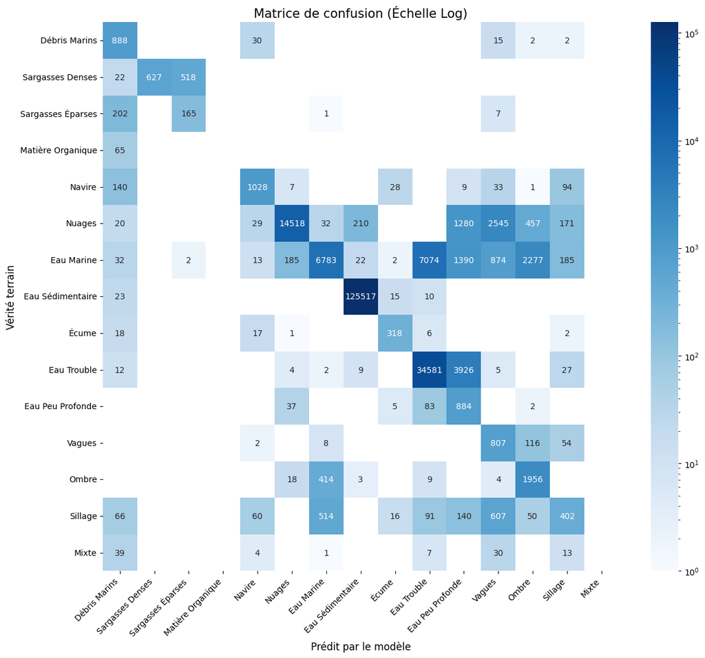

```python
class_names = [CLASS_NAMES[i] for i in range(15)]


def plot_confusion_matrix(model, loader, device):
    print(" Calcul de la matrice de confusion en cours...")
    model.eval()

    all_preds = []
    all_targets = []

    with torch.no_grad():
        for img, mask, conf in tqdm(loader, desc="Validation"):
            img = img.to(device)
            mask = mask.to(device)
            conf = conf.to(device)

            # Même pipeline que train/éval
            ignore_mask = build_conf_ignore_mask(conf, threshold=2)
            target = apply_ignore_index_to_target(mask, ignore_mask, ignore_index=-100)

            valid_pixels = (target != -100)
            target[valid_pixels] = target[valid_pixels] - 1
            target[target == -1] = -100

            outputs = model(img)
            preds = torch.argmax(outputs, dim=1)

            mask_valide = (target != -100)
            all_preds.append(preds[mask_valide].cpu().numpy())
            all_targets.append(target[mask_valide].cpu().numpy())

    y_pred = np.concatenate(all_preds)
    y_true = np.concatenate(all_targets)

    cm = confusion_matrix(y_true, y_pred, labels=range(15))

    plt.figure(figsize=(14, 12))
    sns.heatmap(
        cm,
        annot=True,
        fmt="d",
        cmap="Blues",
        xticklabels=class_names,
        yticklabels=class_names,
        norm=LogNorm()
    )
    plt.xlabel('Prédit par le modèle', fontsize=12)
    plt.ylabel('Vérité terrain', fontsize=12)
    plt.title('Matrice de confusion (Échelle Log)', fontsize=15)
    plt.xticks(rotation=45, ha='right')
    plt.yticks(rotation=0)
    plt.show()


# Lancement
plot_confusion_matrix(model, val_loader, DEVICE)
```

### **Modèle 2 : ResNet**

```python
import torchvision.models as models
import torch.nn as nn
import torch.nn.functional as F
```

1. Modèle ResNet de segmentation

```python
class ResNetSeg(nn.Module):
    """
    Modèle de segmentation basé sur ResNet34 :
    - Encoder : ResNet34
    - Decoder simple : conv 1x1 + upsample bilinéaire à la taille d'entrée
    Adapté à 11 canaux en entrée et 15 classes en sortie.
    """
    def __init__(self, n_channels=11, n_classes=16):
        super().__init__()

        # On part d'un ResNet34 de torchvision (non pré-entraîné pour éviter les soucis de poids)
        base = models.resnet34(weights=None)
        enc_out_channels = 512  # dimension finale de feature map

        # Adapter la première couche à 11 canaux au lieu de 3
        old_conv = base.conv1
        base.conv1 = nn.Conv2d(
            n_channels,
            old_conv.out_channels,
            kernel_size=old_conv.kernel_size,
            stride=old_conv.stride,
            padding=old_conv.padding,
            bias=False,
        )
        # Init Kaiming pour la nouvelle conv
        nn.init.kaiming_normal_(base.conv1.weight, mode="fan_out", nonlinearity="relu")

        # On garde les blocs du ResNet comme "encoder"
        self.stem = nn.Sequential(
            base.conv1,
            base.bn1,
            base.relu,
            base.maxpool,
        )
        self.layer1 = base.layer1
        self.layer2 = base.layer2
        self.layer3 = base.layer3
        self.layer4 = base.layer4

        # Tête de segmentation : conv 1x1 vers n_classes
        self.classifier = nn.Conv2d(enc_out_channels, n_classes, kernel_size=1)

    def forward(self, x):
        # On garde la taille d'entrée pour upsample ensuite
        input_size = x.shape[-2:]  # (H, W)

        x = self.stem(x)      # /4
        x = self.layer1(x)    # /4
        x = self.layer2(x)    # /8
        x = self.layer3(x)    # /16
        x = self.layer4(x)    # /32

        logits = self.classifier(x)  # (B, n_classes, H/32, W/32)

        # Upsampling bilinéaire jusqu'à la taille d'entrée
        logits = F.interpolate(
            logits,
            size=input_size,
            mode="bilinear",
            align_corners=False
        )
        return logits
```

2. Instanciation, loss et optimizer

Ici, on réutilise DEVICE, class_weights et le même type de loss que pour U-Net

```python
model_resnet = ResNetSeg(n_channels=11, n_classes=15).to(DEVICE)

optimizer_resnet = optim.Adam(model_resnet.parameters(), lr=1e-4)

# loss pondérée
criterion_resnet = nn.CrossEntropyLoss(weight=class_weights, ignore_index=-100)

EPOCHS_RESNET = 15
print("Modèle ResNetSeg initialisé avec loss pondérée (débris très importants).")
```

```
Modèle ResNetSeg initialisé avec loss pondérée (débris très importants).
```

3. Boucle d'entraînement

```python
print("\n Lancement de la boucle d'entraînement (ResNetSeg)...")

for epoch in range(EPOCHS_RESNET):
    model_resnet.train()
    epoch_loss = 0.0
    loop = tqdm(train_loader, desc=f"[ResNet] Epoch {epoch+1}/{EPOCHS_RESNET}")

    for img, mask, conf in loop:
        img = img.to(DEVICE)
        mask = mask.to(DEVICE)
        conf = conf.to(DEVICE)

        # Même pipeline que pour le U-Net
        ignore_mask = build_conf_ignore_mask(conf, threshold=2)
        target = apply_ignore_index_to_target(mask, ignore_mask, ignore_index=-100)

        valid = (target != -100)
        target[valid] = target[valid] - 1
        target[target == -1] = -100

        optimizer_resnet.zero_grad()
        outputs = model_resnet(img)          # (B, 15, H, W)
        loss = criterion_resnet(outputs, target)
        loss.backward()
        optimizer_resnet.step()

        epoch_loss += loss.item()
        loop.set_postfix(loss=loss.item())

    # Sauvegarde du modèle ResNet après chaque epoch
    save_dir = os.path.join(PROJECT_PATH, "models")
    os.makedirs(save_dir, exist_ok=True)
    torch.save(model_resnet.state_dict(), os.path.join(save_dir, "resnet_seg_latest.pth"))

print(" Entraînement ResNet terminé et modèle sauvegardé !")
```

```
 Lancement de la boucle d'entraînement (ResNetSeg)...
```

```
 Entraînement ResNet terminé et modèle sauvegardé !
```

4. Evaluation du modèle

```python
# On réutilise la même fonction d'évaluation que pour U-net
evaluate_model_complete(model_resnet, val_loader, DEVICE)
```

```
Calcul des scores en cours (F1, IoU, Précision)...
```

```
---  RÉSULTATS ---
F1-Score (Macro) : 0.1947
Mean IoU : 0.1470

--- RAPPORT DÉTAILLÉ PAR CLASSE ---
                   precision    recall  f1-score   support

    Débris Marins      0.022     0.748     0.043       937
 Sargasses Denses      0.013     0.634     0.025      1167
Sargasses Éparses      0.000     0.000     0.000       375
Matière Organique      0.000     0.000     0.000        65
           Navire      0.302     0.455     0.363      1340
           Nuages      0.971     0.495     0.655     19262
       Eau Marine      0.860     0.597     0.705     18839
 Eau Sédimentaire      0.000     0.000     0.000    125565
            Écume      0.022     0.058     0.032       362
      Eau Trouble      0.934     0.833     0.881     38566
 Eau Peu Profonde      0.006     0.267     0.012      1011
           Vagues      0.020     0.177     0.036       987
            Ombre      0.105     0.233     0.145      2404
          Sillage      0.015     0.048     0.022      1946
            Mixte      0.000     0.000     0.000        94

         accuracy                          0.263    212920
        macro avg      0.218     0.303     0.195    212920
     weighted avg      0.337     0.263     0.286    212920
```

5. Matrice d confusion

```
 Calcul de la matrice de confusion en cours...
```

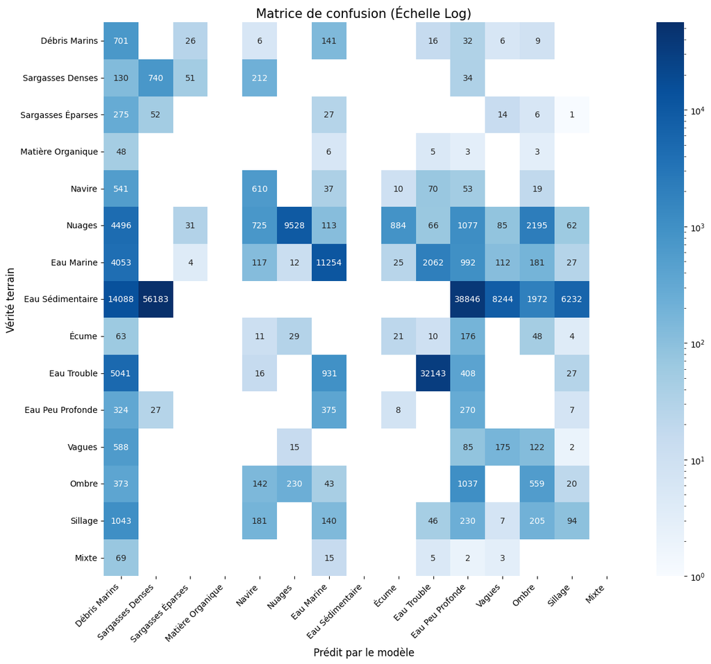

```python
plot_confusion_matrix(model_resnet, val_loader, DEVICE)
```

### **Modèle 3: VGG 16**

1. Modèle de segmentation basé sur VGG16

```python
class VGG16Seg(nn.Module):
    """
    Modèle de segmentation basé sur VGG16 :
    - Encoder : VGG16 (features seulement)
    - Decoder simple : conv 1x1 + upsample bilinéaire à la taille d'entrée
    Adapté à 11 canaux en entrée et 15 classes en sortie.
    """
    def __init__(self, n_channels: int = 11, n_classes: int = 16):
        super().__init__()

        # On part d'un VGG16 avec batch norm, sans poids pré-entraînés
        base = models.vgg16_bn(weights=None)
        features = base.features

        # Adapter la première couche à 11 canaux au lieu de 3
        first_conv = features[0]
        new_conv = nn.Conv2d(
            in_channels=n_channels,
            out_channels=first_conv.out_channels,
            kernel_size=first_conv.kernel_size,
            stride=first_conv.stride,
            padding=first_conv.padding,
            bias=(first_conv.bias is not None),
        )
        # Initialisation Kaiming pour la nouvelle conv
        nn.init.kaiming_normal_(new_conv.weight, mode="fan_out", nonlinearity="relu")
        if new_conv.bias is not None:
            nn.init.constant_(new_conv.bias, 0.0)

        features[0] = new_conv
        self.encoder = features

        # Récupérer le nombre de canaux en sortie du backbone (normalement 512 pour VGG16)
        last_channels = None
        for m in reversed(self.encoder):
            if isinstance(m, nn.Conv2d):
                last_channels = m.out_channels
                break
        if last_channels is None:
            last_channels = 512

        # "Decoder" minimal : conv 1x1 vers n_classes
        self.classifier = nn.Conv2d(
            in_channels=last_channels,
            out_channels=n_classes,
            kernel_size=1
        )

    def forward(self, x: torch.Tensor) -> torch.Tensor:
        """
        Args:
            x: (B, n_channels, H, W)
        Returns:
            logits: (B, n_classes, H, W) — scores par pixel
        """
        input_size = x.shape[2:]  # (H, W) pour l'upsampling final

        x = self.encoder(x)               # (B, C_enc, H', W')
        logits = self.classifier(x)       # (B, n_classes, H', W')

        # Upsampling bilinéaire à la taille d'entrée
        logits = F.interpolate(
            logits,
            size=input_size,
            mode="bilinear",
            align_corners=False
        )
        return logits
```

2. Instanciation modèle et loss et optimizer

```python
model_vgg = VGG16Seg(n_channels=11, n_classes=15).to(DEVICE)
criterion = nn.CrossEntropyLoss()
optimizer = optim.Adam(model_vgg.parameters(), lr=1e-5)
```

3. Boucle d'entrainement

```python
num_epochs = 15
train_losses = []
val_losses = []

for epoch in range(num_epochs):
    model_vgg.train()
    running_loss = 0.0
    loop = tqdm(train_loader, desc=f"[VGG16] Epoch {epoch+1}/{num_epochs}")

    for images, labels, mask_conf in loop:
            images = images.to(DEVICE)
            labels = labels.to(DEVICE)
            mask_conf = mask_conf.to(DEVICE)

            optimizer.zero_grad()

            outputs = model_vgg(images)

            # Get the number of classes the model predicts
            n_classes = outputs.shape[1]

            # ----------------------------------------------------------
            # 1. APPLY MASKS & FIX LABELS
            # ----------------------------------------------------------
            labels_masked = labels.clone()

            # A. Apply your logic for low confidence
            labels_masked[mask_conf > 2] = -100

            # B. THE FIX: Ignore ANY label that is too big for the model
            # This handles 255, background classes, or off-by-one errors automatically.
            labels_masked[labels_masked >= n_classes] = -100

            # ----------------------------------------------------------

            loss = criterion(outputs, labels_masked)

            loss.backward()
            optimizer.step()

            running_loss += loss.item()
            loop.set_postfix(loss=loss.item())

    avg_train_loss = running_loss / len(train_loader)
    train_losses.append(avg_train_loss)

    # ------------------- VALIDATION -------------------
    model_vgg.eval()
    val_running_loss = 0.0

    # ... inside the validation loop ...
    with torch.no_grad():
        for images, labels, mask_conf in val_loader:
            images = images.to(DEVICE)
            labels = labels.to(DEVICE)
            mask_conf = mask_conf.to(DEVICE)

            outputs = model_vgg(images)
            n_classes = outputs.shape[1]  # <--- Get class count

            labels_masked = labels.clone()
            labels_masked[mask_conf > 2] = -100

            # ADD THE FIX HERE TOO:
            labels_masked[labels_masked >= n_classes] = -100

            loss = criterion(outputs, labels_masked)
            val_running_loss += loss.item()

    avg_val_loss = val_running_loss / len(val_loader)
    val_losses.append(avg_val_loss)

    print(f"Epoch [{epoch+1}/{num_epochs}] — Train Loss: {avg_train_loss:.4f} | Val Loss: {avg_val_loss:.4f}")
```

```
Epoch [1/15] — Train Loss: 1.7405 | Val Loss: 1.1106
```

```
Epoch [2/15] — Train Loss: 0.6324 | Val Loss: 0.5189
```

```
Epoch [3/15] — Train Loss: 0.3504 | Val Loss: 0.3485
```

```
Epoch [4/15] — Train Loss: 0.2306 | Val Loss: 0.2255
```

```
Epoch [5/15] — Train Loss: 0.1720 | Val Loss: 0.1597
```

```
Epoch [6/15] — Train Loss: 0.1366 | Val Loss: 0.1356
```

```
Epoch [7/15] — Train Loss: 0.1172 | Val Loss: 0.1169
```

```
Epoch [8/15] — Train Loss: 0.1022 | Val Loss: 0.0946
```

```
Epoch [9/15] — Train Loss: 0.0940 | Val Loss: 0.0901
```

```
Epoch [10/15] — Train Loss: 0.0864 | Val Loss: 0.0871
```

```
Epoch [11/15] — Train Loss: 0.0776 | Val Loss: 0.0826
```

```
Epoch [12/15] — Train Loss: 0.0769 | Val Loss: 0.0723
```

```
Epoch [13/15] — Train Loss: 0.0713 | Val Loss: 0.0635
```

```
Epoch [14/15] — Train Loss: 0.0712 | Val Loss: 0.1006
```

```
Epoch [15/15] — Train Loss: 0.0695 | Val Loss: 0.0649
```

4. Evaluation du modèle

```python
evaluate_model_complete(model_vgg, val_loader, DEVICE)
```

```
Calcul des scores en cours (F1, IoU, Précision)...
```

```
---  RÉSULTATS ---
F1-Score (Macro) : 0.0012
Mean IoU : 0.0006

--- RAPPORT DÉTAILLÉ PAR CLASSE ---
                   precision    recall  f1-score   support

    Débris Marins      0.009     1.000     0.018       937
 Sargasses Denses      0.000     0.000     0.000      1167
Sargasses Éparses      0.000     0.000     0.000       375
Matière Organique      0.000     0.000     0.000        65
           Navire      0.000     0.000     0.000      1340
           Nuages      0.000     0.000     0.000     19262
       Eau Marine      0.000     0.000     0.000     18839
 Eau Sédimentaire      0.000     0.000     0.000    125565
            Écume      0.000     0.000     0.000       362
      Eau Trouble      0.000     0.000     0.000     38566
 Eau Peu Profonde      0.000     0.000     0.000      1011
           Vagues      0.000     0.000     0.000       987
            Ombre      0.000     0.000     0.000      2404
          Sillage      0.000     0.000     0.000      1946
            Mixte      0.000     0.000     0.000        94

         accuracy                          0.004    212920
        macro avg      0.001     0.067     0.001    212920
     weighted avg      0.000     0.004     0.000    212920
```

5. Confusion matrix

```
 Calcul de la matrice de confusion en cours...
```

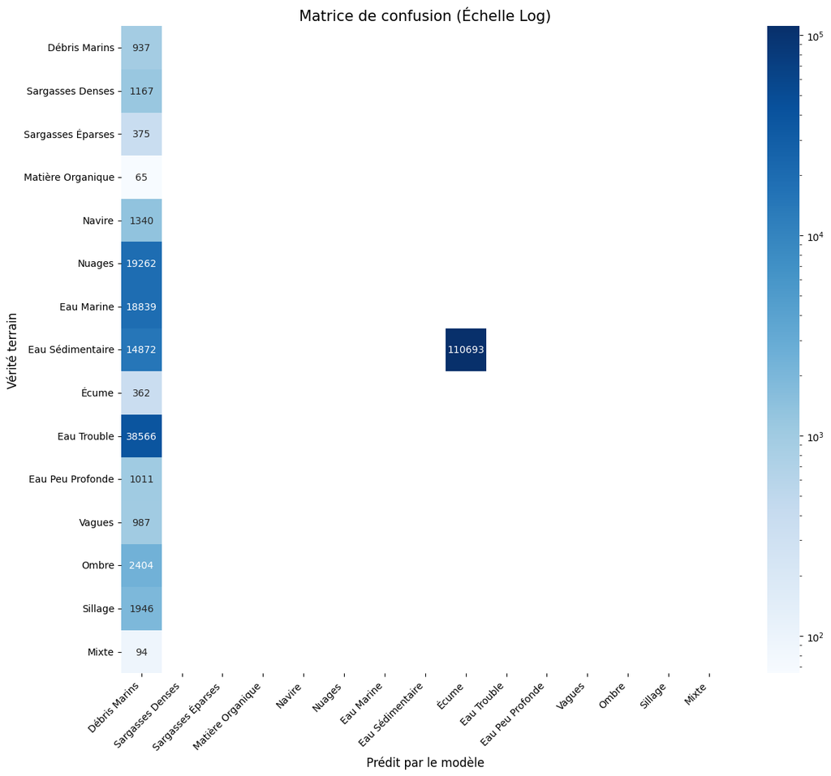

```python
plot_confusion_matrix(model_vgg, val_loader, DEVICE)
```